# Bootstrapping Continued

Day 12

Claire Kelling

Carleton College  
STAT 120 - Fall 2026

## Question of the Day

What is one “weird”/odd thing about you? 😊😝

## Today’s Topics

Logistics:

- R Lab Manual updated this year (please let me know if you ever notice something not lining up!)
- Short report recap: working in groups
- Quiz 2: study guide posted, includes today’s material, quiz will only be half of Friday’s class
- Thursday office hours: cancelled! Email/Slack me if you need an appointment on Wednesday or Thursday. I will still have drop-in hours on Wednesday.
- Happy Indigenous People’s Day! Scientist of the Day: Chris Anderson (Univ. of Alberta)

Topics covered today:

- Level of Confidence
- Bootstrap Percentile Method
- Bootstrapping in R

# Level of Confidence

## Level of Confidence

Which is wider: a 95% confidence interval or a 99% confidence interval?

1. 95% CI
2. 99% CI

99%. We need a larger interval (range of likely parameter values) to have more confidence.

## Other Levels of Confidence

**Levels of Confidence**

- We are 95% confident that the average commute distance for Atlanta workers is between 16.92 and 19.39 miles.
- We can use the 95% rule to help us with this calculation (MOE = 2 $\times$ SE)
- How might you produce a 99% confidence interval for the average commute distance?

## Atlanta Commutes

- In **bell-shaped** bootstrap distributions, we know `estimate` $\pm$ `2(SE)` (approx.) equals the 2.5 and 97.5 percentiles of the distribution.

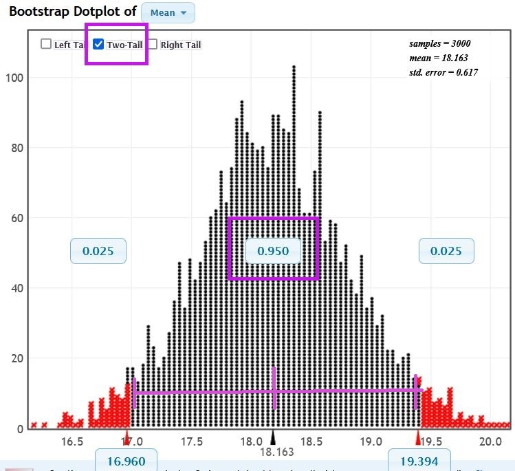

$\bar{x}$ - 2(SE) $\bar{x}$ + 2(SE)

## Example: Atlanta Commutes

- For 99% confidence level, we use the 0.5 and 99.5 percentiles of the bootstrap distribution
- (This is wider than the 2.5 and 97.5 percentiles)

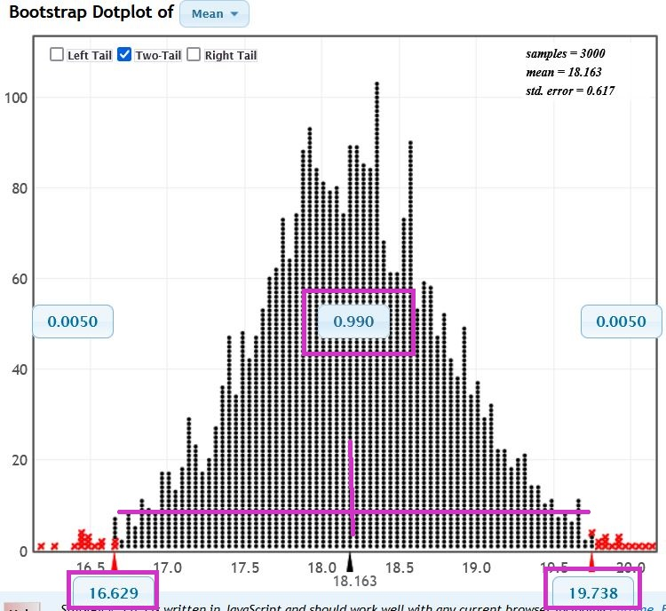

# Bootstrap CI, Percentile Method

## Percentile Method

**Percentile Method of Bootstrapping**

## Confidence Interval, Percentile Method

A P% confidence interval: lower to upper bound

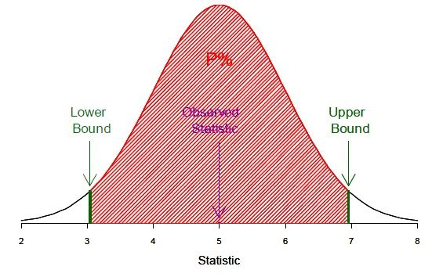

## Example: Atlanta Commutes

**Method 1 (SE)**

95% confidence interval for the average commute distance for Atlantans is 16.92 to 19.39 miles.

$$18.16 \pm 2 \times 0.618$$

**Method 2 (percentiles)**

Basically the same because of the bell-shaped bootstrap distribution.

When **won’t** they be similar?

- If it wasn’t bell-shaped, the answers would be different and you should use Method 2 (percentiles).

## Example: Atlanta Commutes, 99% CI

**Method 2 (We use the percentile method)**

As expected, this is wider than the 95% CI.

## Use of Bootstrapping

**Bootstrapping Use**

We can use bootstrapping to approximate the SE for many types of sample statistic!

- Mean, proportion, differences, correlation, slope
- Standard deviation*, median*

**Shape of Bootstrap Distribution**

What should the bootstrap distribution look like?

- It should be **“smooth”** (i.e. not a lot of spikey-ness)
- If using Method 1 for 95% CI ($\pm$ 2SE), should be symmetric and bell-shaped.

## Example: Mercury and pH in Lakes

- For Florida lakes, what is the correlation between average mercury level (ppm) in fish taken from a lake and acidity (pH) of the lake?
- $r = -0.575$ for the sample below
- **Goal:** Give a 90% CI for $\rho$

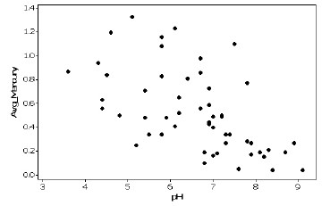

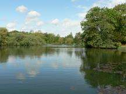

Lange, Royals, and Connor, Transactions of the American Fisheries Society (1993)

## Example: Mercury and pH in Lakes

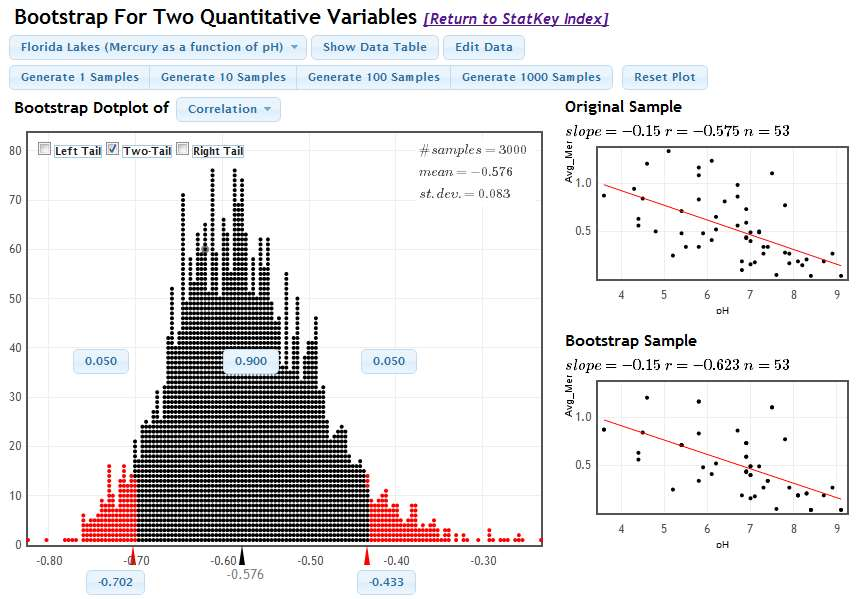

We are 90% confident that the true correlation between average mercury level and pH of Florida lakes is between -0.702 and -0.433.

## Bootstrap Cautions

**Words of Caution**

- These methods for creating a confidence interval only work if the bootstrap distribution is smooth and symmetric
- **ALWAYS** look at a plot of the bootstrap distribution!
- If the bootstrap distribution is highly skewed or looks “spiky” with gaps, you will need to go beyond intro stat to create a confidence interval

## Bootstrap Cautions

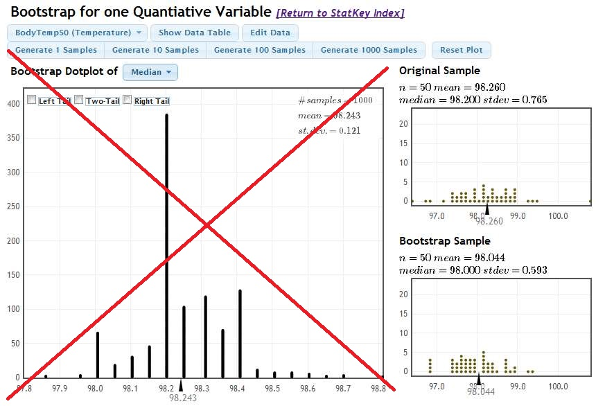

- Spiky, not smooth

## Number of Bootstrap Samples

- When using bootstrapping, you may get a slightly different confidence interval each time. This is fine!
- The more bootstrap samples you use, the more precise your answer will be.
- For the purposes of this class, 1,000 bootstrap samples is fine. In real life, you probably want to take 10,000 or even 100,000 bootstrap samples

# Bootstrapping in R

## Bootstrapping in R

**One variable**

```r
boot(~var_name, data = dat_name, conf.level = 0.95)
```

Bootstrapping one variable (var_name), either a numeric or categorical variable

`conf.level` specifies the confidence level for the percentile interval

**Bootstrapping a difference**

```r
boot(num_var ~ factor_var, data = dat_name, conf.level = 0.95)
```

- Bootstrapping a difference, either a proportion or mean, in num_var by factor variable
- Factor variable (factor_var) must be 2 levels
- For a difference in proportions, the first variable (num_var) must be coded as 0/1

## Bootstrapping in R

Output:

- Observed data
- Mean and SE of bootstrap distribution
- 95% **percentile** interval and histogram of bootstrap dist

## Bootstrapping in R

```r
boot(~wingspan_inches, data=nba)
```

```
    ** Bootstrap interval for mean

 Observed  wingspan_inches : 82.59487
 Mean of bootstrap distribution: 82.59309
 Standard error of bootstrap distribution: 0.18228

 Bootstrap percentile interval
    2.5%    97.5%
82.23747 82.94990

        *--------------*
```

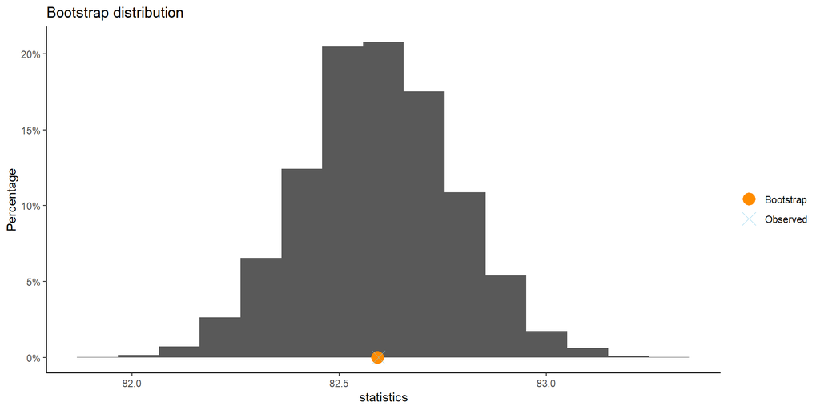

## Bootstrapping in R

**Paired Data**

- Have data on the same individual for two variables
- Bootstrap difference in variables for the same individual (ex: resident vs nonresident tuition for US colleges)

```r
bootPaired(var_1 ~ var_2, data = dat_name)
```

**Bootstrapping correlation**

- Bootstrapping correlation for two quantitative variables (ex: resident vs nonresident tuition for US colleges)

```r
bootCor(var_1 ~ var_2, data = dat_name)
```

# Final Details

## Bootstrapping to estimate $\mu, p$

**One Parameter, estimating $\mu, p$**

- Your sample could be considered similarly to a bag of marbles
- Each of those marbles have data associated with them: a number or a category written on them
- You take one marble out, record the data value on it, put it back.
- Repeat until you have the same number of values written as original sample (# of marbles in the bag)
- This information will be used to generate **one** bootstrap statistic

## Bootstrapping to estimate Difference

**Difference in Means or Proportions (estim. $\mu_1 - \mu_2$ or $p_1 - p_2$)**

- Want to make the bootstrapped sample similar to original sample
- Sample with replacement **from each category** (1 and 2) for same sample size *within the category*
- Recompute $\bar{x}_1$ and $\bar{x}_2$ to get the bootstrap statistic ($\bar{x}_1$ - $\bar{x}_2$)

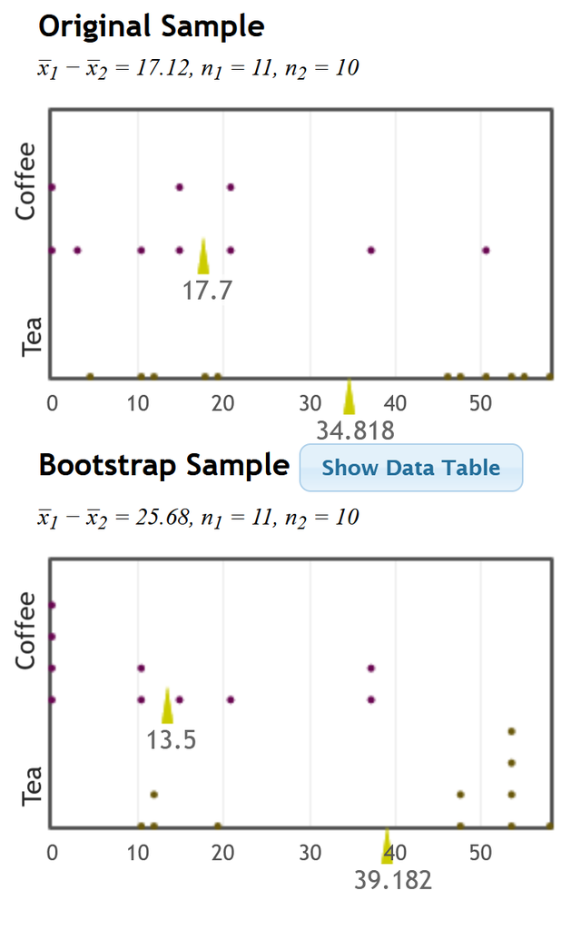

## How to get CI in StatKey

[figure not shown]

## Summary

**Bootstrap CI Option 1**

Estimate the standard error of the statistic by computing the standard deviation of the bootstrap distribution, and then generate a 95% confidence interval by

statistic $\pm$ 2(SE)

**Bootstrap CI Option 2**

Generate a P% confidence interval using the middle P% of bootstrap statistics and finding the associated percentiles

**Important Note**

Note the differences in the following distributions:

- Population, data, sampling, bootstrap

## Bootstrapping Practice: Bootstrap CI for a Difference

**Goal:** The data set CreditData.csv contains records for 1000 loans that either defaulted (BadLoan) or did not default (GoodLoan). Let’s look at the mean age of individuals for each type of loan (good or bad).

Have **one** person pull up the handout in R using the code for today’s class. Everyone will then write the answers to what you find on the physical handout.

The code is explained in detail so that you’ll understand what it is doing, but for today in-class, let’s focus on using the code to answer the questions on the handout.